# TP3

Moussa NGAMBE

07/04/2023

# TP3 Calibrer/ évaluer une méthode et la comparer à d’autres

## Partie 1 : Les objectifs

- Savoir évaluer correctement les performances d’une méthode de classifiction.
- Savoir utilser les approches par découpage apprentissage/ test répété et par validation croisée *(LOO et K-fods)*.

#### 1. Chargement des données et packages class

```r
library(class)
load("/Users/moussangambe/Desktop/R/AprentissageSupervise/TP3/simu_gauss2.rda")
```

#### 2. L’approche par découpage apprentissage/ test répété.

1. Le code ci-dessous permet d’estimer le taux d’erreur de la méthode *knn* (avec k = 15 voisins) en découpant aléatoirement les 1000 données en 80% de données d’apprentissage et 20% de données test et en estimant le taux d’erreur par *le taux d’erreur test*.

```r
# Tirage aléatoire des indices des 800 observation
tr<-sample(1:nrow(X),800)
# Echantillon d'apprentissage
Xtrain<-X[tr,]
Ytrain<-Y[tr]
# Echantillon test
Xtest<-X[-tr,]
Ytest<-Y[-tr]
# Prédiction des 200 données test
pred_test<-knn(Xtrain, Xtest, Ytrain, k=15)
# erreur test pour 1 découpage
sum(pred_test!=Ytest)/length(Ytest)
```

```
## [1] 0.17
```

#### Commentaire :

Si on execute le code ci-dessus plusieurs fois on constate que le taux d’erreur test est différent à chaque fois. Il faut donc tenir compte de cette dépendance du taux d’erreur test au découpage et répéter plusieurs fois la procédure de découpage apprentissage/test.

2. Afin de tenir de la dépendance du taux d’erreur test au découpage, on répète *B = 100* fois la procédure. Le code ci-dessous effectue ainsi B = 100 découpages aléatoires et stocke les 100 valeurs de taux d’erreur test dans un vecteur de taille *B*. On peut alors calculer un taux d’erreur test moyen en faisant la moyenne des 100 valeurs obtenues avec les B = 100 découpages.

```r
B <- 100 # nombre de découpages
err_test <- rep(NA,B) # vecteur pour stocker les B erreurs tests
for (b in 1:B)
{
tr <- sample(1:nrow(X), 800)
Xtrain <- X[tr,]
Ytrain <- Y[tr]
Xtest <- X[-tr,]
Ytest <- Y[-tr]
pred_test <- class::knn(Xtrain, Xtest, Ytrain, k=15)
err_test[b] <- sum(pred_test!=Ytest)/length(Ytest)
}
mean(err_test) # erreur test moyenne
```

```
## [1] 0.18665
```

#### Commentaire

Nous trouvons un taux d’erreur moyen autour de $18\%$.

3. Visualiser la variabilité des taux d’erreurs test avec un boxplot.

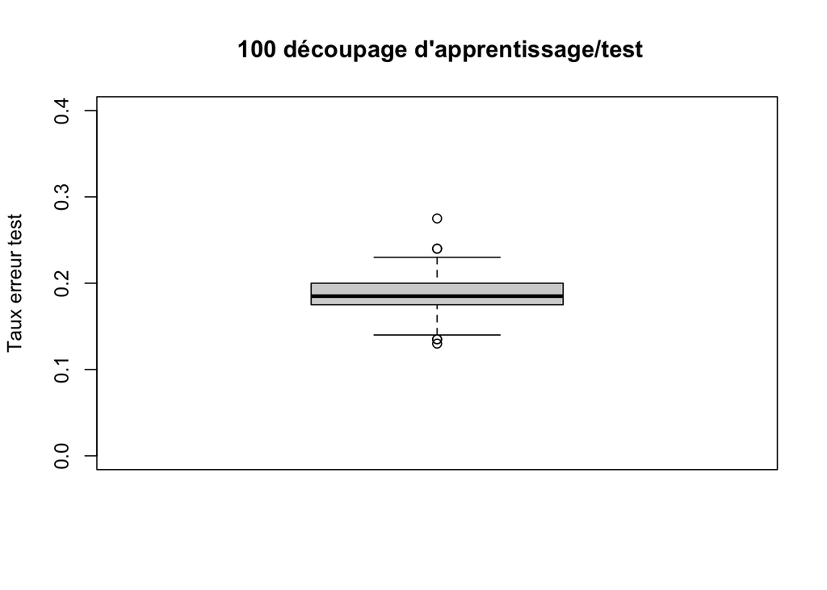

```r
boxplot(err_test, ylab="Taux erreur test", ylim=c(0,0.4),
        main=" 100 découpage d'apprentissage/test")
```

#### Commentaire

Le taux d’erreur test médiane est autour de $18\%$ avec une certaine variabilité autour de cette valeur.

```r
summary(err_test)
```

```
##    Min. 1st Qu.  Median    Mean 3rd Qu.    Max.
##  0.1300  0.1750  0.1850  0.1867  0.2000  0.2750
```